# INTRODUCTION TO MACHINE LEARNING

## Linear Regression

- Email: cross224@hotmail.com
- GitHub: [@carap](https://github.com/carap)

# MACHINE LEARNING

# General workflow (*pipeline*)

Most projects can be thought of as a series of discrete steps:

- Data acquisition/loading and preprocessing
- Feature creation, selection, and normalization
- Model building (multiple models combined) and testing
- Reporting/Deployment

[figure not shown]

> *NOTE*: We've firstly worked with **DATA**, but now we have to deal with **MODELS**!

# Machine learning

Broad notion of building **computational structures** that progressively *learn* based on **experience**

- In fact, it is not just about building this *structures*, but the *math, science, engineering, stats, and the computing* behind these structures for gleaning **information** from historical data sets, in order to process new data sets.

# Machine Learning Modelling

A very **interdisciplinary field**...

- Cognitive Neuroscience and Artificial Intelligence
- Information and Control theory
- Stochastic signal processing, and Statistical Learning
- Frequentist and Bayesian statistics
- Functional analysis (transforms) and Calculus (derivatives)
- Linear algebra, Linear programming and Matrix analysis
- Optimization, Numerical methods, and Error Analysis
- ... a lot of programming!

# Our agenda

### ... so far

- How we use **Numpy/Pandas library** for *reading* data
- How we use **Matplotlib/Seaborn library** for *visualizing* data

### onwards...

- What is **linear regression**, and how does it work?
- How do we **train** and **interpret** a linear regression model?
- What are some **evaluation metrics** for regression problems?
- How do we choose **which features to include** in my model?

# Machine learning taxonomy

#### Supervised learning (*function aproximation*)

- Classification and Regression
  - goal: learn $f(x)$ from $\{(x_i,y_i)\}_{i=1}^{n}$
  - target function: $f(x)$
  - learned (estimated) function: $\hat{f}(x)$
  - training sample: $\{(x_i,y_i)\}$

# Machine learning taxonomy

#### Unsupervised learning (*data summarization*)

- Clustering, **Dimentionality reduction**
  - goal: learn $f(x)$ from $\{x_i\}_{i=1}^{n}$
  - target function: $f(x)$
  - learned (estimated) function: $\hat{f}(x)$
  - training sample: $\{x_i\}$

# Machine learning taxonomy

#### Reinforcement learning (*scoring*)

- Learning + **Dynamic control**
- Environment-driven **behavior**
- Cummulative **reward maximization**
  - utility theory, decision making, game theory

# Machine learning taxonomy

We can formulate all of these different problems as some form of optimization

- Supervised learning
- Unsupervised learning
- Reinforcement learning

> **Bib.Ref.** *Optimization by Vector Space Methods*, **David G. Luenberger**
> - Department of Management Science and Engineering, Stanford University.

# Calculus breviary

# Arithmetic fundamentals

Do you remember Arithmetic?

Following priority rules, get the results of the arithmetic operations below

### $Q1$: $ 9 - 3 \div \frac{1}{3} + 1$

### $Q2$: $\frac{ \sqrt{5^{-2}\cdot{\sqrt[3]{5^{-3}\cdot5^{-3}}} } }{5^{-2}}$

```python
# Q1
9 - (3 * (3**(-1))**(-1)) + 1
```

```
1.0
```

```python
# Q2
( (5**(-2)) * (5**(-3)*5**(-3))**(1/3) )**(1/2) / 5**(-2)
```

```
1.0
```

# Calculus fundamentals

**Calculus** is very different from arithmetic, algebra and geometry

- **calculus** is less static and more *dynamic*
- it is concerned with *change* and *motion*
- it deals with quantities that *approximate* other quantities.

# Calculus fundamentals

The primary building blocks or **abstract objects** that we deal with in calculus are **functions**.

There are four possible ways to represent a function:

- verbally (description in words)
- numerically (by a table of values)
- visually (by a graph)
- **algebraically** (by explicit **formulas**)
  - a concise way of expressing information **symbolically** about the **relationship** between given quantities.

# What is a function?

We may think about functions in many different ways, but there are always three main parts:

- the **input**, the **relationship**, and the **output**

An "*intuitive explanation*" of function would be as follows:

> Def.1. A function is an **association rule** that *relates* **each element** of a **set** with **exactly one element** of another set (possibly the same set).
> 1. "*each element*" means that every element in some set $X$ is related to some element in another set $Y$.
>    - some elements of $Y$ might not be related to at all, which is fine
> 2. *"exactly one"* means that a function is **single-valued** ( *emphatic term*)
>    - It will not give back *two or more* results for the same input

# What is a function?

We can think of functions like **machines** that *associate/map* inputs to outputs

> **NOTE**: The use of the term *machine* is due to historical reasons
> - Evolution from fully-mechanical, to electro-mechanical to fully-electronic computers
> - ACM (1947) Association for Computer Machinery

[figure not shown]

# What is a function?

This *intuitive explanation* of functions would be completed with a **formal definition**, which relies on the notion of the **Cartesian product of two sets** (*direct product of groups*).

> Def. 2. The **Cartesian product** of two sets $X$ and $Y$ is the set of all **ordered pairs**, written $(x, y)$, where $x$ is an element of $X$ and $y$ is an element of $Y$.
> - $x$ and the $y$ are called the **components** of the **ordered pair**.
> - the *Cartesian product* of $X$ and $Y$ is denoted by $X\times Y$.
> - $X\times Y = \{ \;(x,y)\; | \; x\in X, y\in Y \}$
> - $G_1\times G_2 = \{ \;(x,y)\; | \; x\in G_1, y\in G_2 \}$

# What is a function?

A function $f$ is commonly declared by stating its **domain** $X$ and **codomain** $Y$ using expressions like:

- $f: X\to Y$ (e.g., $f:\mathbb R^2\to\mathbb R$)
- $ X \xrightarrow{f} Y$
- $ f\{X\}= Y$
- $f(x) = y$

When written as $f(x)$, the elements $x\in X$ are called arguments of $f$

- for each argument $x\in X$, the corresponding unique element in the codomain is called the **function value** at $x$, or the **image** of $x$ *under* $f$.

# When two functions are the same?

Two functions are the same if they have the **same output for each input**

- Arithmetic method (tabular)
- Algebraic method (solve equations)

> This is a fundamental idea for **function approximation**

Many problems can be solved *arithmetically* or *algebraically*.

- An algebraic solution is simply a *generalized arithmetic solution*

# When two functions are the same?

#### $Q$: Is $f(x) = (1+x)^2$ the same as $g(x) = x^2 + 2x +1$ ?

# When two functions are the same?

#### $Q$: Is $f(x) = (1+x)^2$ the same as $g(x) = x^2 + 2x +1$ ?

> *Algebraically...* $$ \begin{align*} f(x) &= (1+x)^2 \\ &= (1+x)(1+x) \\ &= 1*(1+x)+ x*(1+x) \\ &= 1*1 + 1*x + x*1 + x*x \\ &= 1^2 + x + x + x^2 \\ &= 1 + 2x + x^2 \\ &= g(x) \end{align*} $$

> *Arithmetically...*

| input value | f(x) | g(x) |
| --- | --- | --- |
| -1 | 0 | 0 |
| 0 | 1 | 1 |
| 1 | 4 | 4 |

# When two functions are the same?

#### $Q$: Is $f(x)=\frac{x^2}{x}$ the same as $g(x) = x $ ?

# When two functions are the same?

#### $Q$: Is $f(x)=\frac{x^2}{x}$ the same as $g(x) = x $ ?

> *Algebraically...* $$ \begin{align*} f(x) &= \frac{x^2}{x}\\ &= (x^2)(x^{-1}) \\ &= (x^{2-1}) \\ &= (x^{1}) \\ &= x \\ &= g(x) \end{align*} $$

> *Arithmetically...*

| input value | f(x) | g(x) |
| --- | --- | --- |
| 2 | 2 | 2 |
| -2 | -2 | -2 |
| 0 | ? | 0 |

# REGRESSION ANALYSIS

# Regression Analysis

1. What is Regression Analysis?
2. Why do we use Regression Analysis?
3. What are the types of Regressions?

# What is Regression Analysis?

**Regression analysis** is a **statistical process** for investigating the **functional relationships** among variables.

**Regression analysis** is a form of **modelling technique** which estimates the **conditional expectation** of *dependent variables* given the *independent variables*.

- the *average value* of the *dependent variable* when the *independent variables* are *fixed*

$$ \mathbf{E}[Y\;|\; \mathbf{X}]$$

The **estimation target** is a **function** of the independent variables called the **regression function**

- It is highly related to *fitting curves* to a given set of points.

# Statistics

Statistics is that *branch of mathematics* that analyzes and presents **inferences** from **data** asssociated to **samples** drawn from the population, instead of the **entire population**.

Concepts to understand population's **moments of distribution**:

- Central tendency, dispersion, shape
- Mean (*first moment*), value around which central clustering occurs
- Variance (*second moment*), degree of variability around the mean
- Skewness (*third moment*), degree of asymmetry of a distribution around its mean
- Kurtosis (*fourth moment*), measure of the *tailedness* of the distribution

[figure not shown]

# Why use Regression Analysis?

Is an important tool for **data analysis** and finding the *cause-effect relationship* between variables

- this technique is used for forecasting, time series modelling

There are multiple benefits of using regression analysis.

- It allows to get insights about **significant relationships** between dependent and independent variables
- It is **highly interpretable** and is basis for other methods
- Allows us to **compare** the effects of variables measured on **different scales**

# What are the types of Regressions?

There are various types of regression techniques available to make predictions.

- Linear, Logistic, Polynomial, Stepwise, Ridge, and Lasso

These techniques are mostly driven by three metrics

1. number of independent variables
2. type of dependent variables
3. shape of regression line (model)

# LINEAR REGRESSION ANALYSIS

# Linear Regression Analysis

It is one of the most widely known technique, and is usually among the first topics people pick while learning *predictive modeling*.

> Nowadays, due to the flood of **big data** emanating from **businesses processes**, companies are adopting **analytic solutions** to extract **meaningfrom data** and to improve **decision making**.

# Linear Regression Analysis

**Business intelligence & analytics** focuses on optimizing CAPEX/OPEX, by applying **statistical and analytical methods** on historical **data**, to understand **business performance**.

> Analytical options are *categorized* into three distinct but complementary types:
> - **Descriptive**, which answer *What has happened?* by using data aggregation and data mining to provide *insight into the past*
> - **Predictive**, which answer *What could happen?* by using statistical and forecasting models to *understand the future*
> - **Prescriptive**, which answer *What should we do?* by using optimization and simulation algorithms to *advice on possible outcomes*.

# Linear Regression Analysis

**Coursera Specializations**:

- Strategic Business Analytics Specialization (4 courses)
- Business Analytics Specialization (5 courses)
- Advanced Business Analytics Specialization
- Excel to MySQL: Analytic Techniques for Business Specialization

# Linear Regression Analysis

In this technique, the **nature of regression is linear**, i.e., it suppose a *linear relationship* between features and response

- **Pros:** fast, highly interpretable, well-understood
- **Cons:** unlikely to produce the best **predictive accuracy**

# Linear Regression Analysis

**Accuracy-Precision** trade-off (a.k.a. *bias-variance trade-off*)

- **Accuracy** is how close a measured/predicted value is to the true value (*constant parameter*).
- **Precision** is how close the measured/predicted values are to each other.

[figure not shown]

# Linear Regression

In this technique, the **dependent variable** is **continuous**, **independent variable**(s) can be **continuous or discrete**

$ \begin{align*} y &= f(\mathbf{x}) \\ &= \beta_0 + \beta_{1}x_{1} + \ldots + \beta_{k}x_{k} + \ldots + \beta_{n}x_{n} \\ &= \sum_{i}^n \beta_{i}x_{i} \\ \end{align*} $

What does each term represent?

- $y$ is the response
- $\beta_0$ is the intercept
- $\beta_1$ is the coefficient for $x_1$ (the $1$st feature)
- $\beta_k$ is the coefficient for $x_k$ (the $k$th feature)
- $\beta_n$ is the coefficient for $x_n$ (the $n$th feature)

# Linear Regression

$ \begin{align*} y &= \beta_0 + \beta_{1}x_{1} + \ldots + \beta_{k}x_{k} + \ldots + \beta_{n}x_{n} \\ &= \sum_{i}^n \beta_{i}x_{i} \\ &= \langle \boldsymbol{\beta} , \mathbf{x} \rangle \\ &= \boldsymbol{\beta}^{\top}\mathbf{x} \end{align*} $

What does each term represent?

- $y$ is the response value
- $\mathbf{x}$ is the feature vector
- $\boldsymbol{\beta}$ is the vector of coefficients

# Linear Regression

$ \begin{align*} y &= f(\mathbf{x}) \\ &= \beta_0 + \beta_{1}x_{1} + \ldots + \beta_{k}x_{k} + \ldots + \beta_{n}x_{n} \\ &= \sum_{i}^n \beta_{i}x_{i} \\ \end{align*} $

> **NOTE**: The $\beta$ values are called the **model coefficients**
> - These values are *learned* during the *model fitting* step using some **optimization criterion**.
> - Then, the **fitted model** can be used to make **predictions**!

# Optimization criterion: error terms

# Simple Linear Regression

Simple linear regression is an approach for predicting a **quantitative response** using a **single feature** (predictor or input variable). It takes the following form:

$y = f(x) = \beta_0 + \beta_1x$

### What does each term represent?

- $y$ is the response (variable we are trying to predict)
- $x$ is the feature (variable we are using to predict)
- $\beta_0$ is the **intercept** (the value of $y$ when $x$=0)
- $\beta_1$ is the **slope** (the change in $y$ divided by change in $x$)

# Learning Model Coefficients

How do the **model coefficients** *relate* to the some **optimization criterion**?

[figure not shown]

# Learning Model Coefficients

Generally, coefficients are *learned* (estimated) using the **least squares criterion**, which means we are looking for a **linear model** (a line), which *minimizes* the **sum of squared residuals** (or *sum of squared errors*):

[figure not shown]

> **NOTE**:
> - The black dots are the **observed values** (given $x$ and $y$).
> - The blue line is our **least squares line**.
> - The red lines are the **errors**, i.e., the *distances* between the observed values and the least squares line.

# Error terms

In a statistical or mathematical model, an **error term** is a **random variable**, which is created when the model does *not fully represent* the actual **relationship** between the independent and dependent variables.

- Essentially means that the model is **not completely accurate**

As a result of this *incomplete relationship*, the error term is a **quantitative measure** of how much our linear model $\hat{f}$ differs from the actual functional relationship $f$.

> Error term represents the **margin of error**, referring to the **sum of the deviations** within the regression line
> - the **error term** is also known as the **residual** or **disturbance**.

# Model evaluation metrics for regression

We need **evaluation metrics** designed for comparing continuous values.

Let's create some example numeric predictions, and calculate **three common evaluation metrics** for regression problems:

- **Mean Absolute Error (MAE)** is the mean of the absolute value of the errors: $$ \frac{1}{n}\sum_{i=1}^n|y_i-\hat{y}_i| $$
- **Mean Squared Error (MSE)** "punishes" larger errors, taking just the mean of the squared errors: $$\frac{1}{n}\sum_{i=1}^n(y_i-\hat{y}_i)^2$$
- **Root Mean Squared Error (RMSE)** is interpretable in the "y" units, since it is the square root of the mean of the squared errors: $$\sqrt{\frac{1}{n} \sum_{i=1}^n(y_i-\hat{y}_i)^2}$$

```python
import numpy as np
# calculate Mean Absolute Error (MAE)
y = np.array([100, 50, 30, 20])
y_hat = np.array([90, 50, 50, 30])
```

**Mean Absolute Error (MAE)** is the mean of the absolute value of the errors:

$$ \begin{align*} \frac{1}{n}\sum_{i=1}^n|y_i-\hat{y}_i| &= \frac{1}{n}(|y_1-\hat{y}_1| + \ldots + |y_n-\hat{y}_n|) \\ \end{align*} $$

```python
# by hand
(10 + 0 + 20 + 10) #/4.
```

```
40
```

```python
( abs(y[0]-y_hat[0]) +
  abs(y[1]-y_hat[1]) +
  abs(y[2]-y_hat[2]) +
  abs(y[3]-y_hat[3]) ) #/4.
```

```
40
```

```python
assert len(y) == len(y_hat)
[ abs(y[i]-y_hat[i])  for  i  in  range(0,len(y)) ]  # list comprehension
```

```
[10, 0, 20, 10]
```

```python
list( zip(y,y_hat) )  # 'tuple' does not support item assignment
```

```
[(100, 90), (50, 50), (30, 50), (20, 30)]
```

```python
[ abs(a[0]-a[1])  for  a  in  zip(y,y_hat)]
```

```
[10, 0, 20, 10]
```

```python
list( map( lambda a:abs(a[0]-a[1]), zip(y,y_hat) ) ) # scatter
```

```
[10, 0, 20, 10]
```

```python
import numpy as np

true_value = np.array([100, 50, 30, 20])
pred_value = np.array([90, 50, 50, 30])

niter = iter(zip(true_value,pred_value))

items = np.array([i for i in niter]) # [0][0]

[ np.abs(item[0]-item[1]) for item in items ]
# np.sum(
# [ np.abs(item[0]-item[1]) for item in items]
# ) * (1/len(items))
```

```
[10, 0, 20, 10]
```

```python
import pandas as pd

true_value = np.array([100, 50, 30, 20])
pred_value = np.array([90, 50, 50, 30])
index = range(1, len(true_value)+1)

niter = iter(zip(true_value, pred_value))
items = pd.Series(data=[i for i in niter], index= index) # .iloc[0][0] #[0][0]

[ pd.Series.abs(item[0]-item[1])  for  item  in  items ]
#pd.Series(
#  [pd.Series.abs(item[0]-item[1]) for item in items]
# ).sum() * (1/len(items))
```

```
[10, 0, 20, 10]
```

```python
# calculate MSE by hand
print((10**2 + 0**2 + 20**2 + 10**2)/4.)
```

```
150.0
```

```python
# calculate RMSE by hand
#print(np.sqrt((10**2 + 0**2 + 20**2 + 10**2)/4.))
print(((10**2 + 0**2 + 20**2 + 10**2)/4.)**(1/2))
```

```
12.24744871391589
```

# LSE vs MSE: fitting vs evaluation

When we want to **build a model** (linear regression in our case), we would usually use the **Least Square Error (LSE)** method

- **minimizing the total euclidean distance** between a line and the data points

  > Theoretically the coefficients of this line can be found using calculus but in practice, an algorithm will perform a **gradient descent** which is faster.

Once we have your model, we want to **evaluate its performance**; thus, in the case of regression, the **Mean Squared Error (MSE)** is good to evaluate *how far in average* is our model from the actual data points (or test dataset).

> **NOTE**: **LSE** is a method that **builds a model**, and **MSE** is a metric that evaluate **model's performance**.

# Linear Regression: Example

Let's suppose we are given the followign dataset:

| point | x | y |
| --- | --- | --- |
| $p_1$ | 1 | 1 |
| $p_2$ | 3 | 2 |

> In this example, we apply linear regression analysis to this sophisticated dataset, and we show how to interpret the results of our analysis.

> We will do the computations manually, since the details are very valuable, in an educational sense.

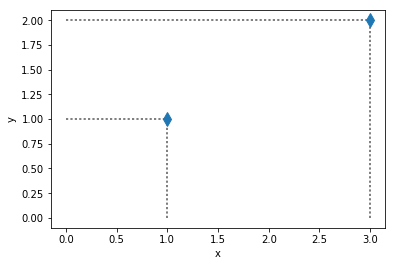

```python
import matplotlib.pyplot as plt
%matplotlib inline

# (1,1), (3,2)
plt.plot([0, 1], [1,1], color='grey', linewidth=2,linestyle='dotted')
plt.plot([1,1],[0,1], color='grey', linewidth=2,linestyle='dotted')
plt.plot([0, 3], [2,2], color='grey', linewidth=2,linestyle='dotted')
plt.plot([3,3],[0,2], color='grey', linewidth=2,linestyle='dotted')
plt.plot([1,3],[1,2], 'd', markersize=10)
plt.xlabel('x')
plt.ylabel('y')
plt.show()
```

In this problem, we are looking for a model that captures the *functional relationship* between these two points.

Using **linear regression** our *hypothesis* is that such *functional relationship* can be **modeled** as a **line**, represented as: $$ \begin{align*} y &= f(x) \\ &= \beta_0 + \beta_{1}x_{1} \\ &= \beta_0 1 + \beta_{1}x_{1} \\ &= \beta_0 x_0 + \beta_{1}x_{1} \quad \text{where $x_0=1$}\\ &= \sum_{i=0}^1 \beta_{i}x_{i} \\ \end{align*} $$

> Do you remember $ y = m x + b$ ?... where $m$ is known as the *slope* and $b$ is the *itercept*

We can rewrite this expression using **vector notation**, where vectors may be *geometric vectors* or *abstract members* of **vector spaces**.

$$ \begin{align*} y &= f(\mathbf{x};\boldsymbol{\beta}) \\ &= \langle \boldsymbol{\beta} , \mathbf{x} \rangle \\ &= \boldsymbol{\beta}\cdot \mathbf{x} \\ &= \boldsymbol{\beta}^{T}\mathbf{x} \\ &= [\beta_0,\beta_1] \begin{bmatrix} x_0\\x_1 \end{bmatrix} \\ &= \beta_0 x_0 + \beta_{1}x_{1} \\ \end{align*} $$

In our problem, since both points *live* in the same line (**linear relationship**), they both should satisfy (*obey*) the same linear model. So let's compute the $\beta$ parameters, which are common for our data points

| point | $x_0$ | $x_1$ | $y$ | Model: $ y = \beta_{0} x_{0} + \beta_1 x_1 $ |
| --- | --- | --- | --- | --- |
| $p_1$ | 1 | 1 | 1 | $1 = \beta_0 (1) + \beta_{1} (1)$ |
| $p_2$ | 1 | 3 | 2 | $2 = \beta_0 (1) + \beta_{1} (3)$ |

These two equations are actually a *$2\times 2$ system of linear algebraic equations*, i.e., **$2$ equations in $2$ unknowns**, which we have to solve, in order to figure out what is the line that *passes* through the points.

$$ \beta_0 (1) + \beta_{1} (1) = 1 \\ \beta_0 (1) + \beta_{1} (3) = 2 $$

Thus, the system may be written as the matrix equation $\mathbf{A} \cdot \boldsymbol{\beta} = \mathbf{y} $, where

$ \mathbf{A}= \begin{bmatrix} 1 & 1 \\ 1 & 3 \\ \end{bmatrix} $, $ \boldsymbol{\beta} = \begin{bmatrix} \beta_{0}\\ \beta_{1} \end{bmatrix} $, $ \mathbf{y}= \begin{bmatrix} 1\\ 2 \end{bmatrix} $

thus, $\mathbf{A} \cdot \boldsymbol{\beta} = \mathbf{y}$ becomes

$$ \begin{bmatrix} 1 & 1 \\ 1 & 3 \\ \end{bmatrix} \cdot \begin{bmatrix} \beta_{0}\\ \beta_{1} \end{bmatrix} = \begin{bmatrix} 1\\ 2 \end{bmatrix} $$

Can you see the **linear combination** of the **column vectors** of our system ?

$$ \begin{bmatrix} 1 \\ 1 \end{bmatrix} \beta_0 + \begin{bmatrix} 1 \\ 3 \end{bmatrix} \beta_1 = \begin{bmatrix} 1\\ 2 \end{bmatrix} $$

Now, we are just coming to the point where we have several **algebraic equations**, so we need **matrices**.

> Do you remember $ \mathbf{A \cdot x} = \mathbf{b}$ and how to solve it? ... where $\mathbf{A}$, $\mathbf{b}$ are *known*, and $ \mathbf{x}$ is *unknown*

# Linear Algebra breviary

# Linear Equations

A **fundamental problem** that commonly arises in all **mathematical sciences** is that of *analyzing and solving* $m$ algebraic equations in $n$ unknowns.

The **problem** is to determine, if possible, a common solution for a system. In general, we have $m$ *linear algebraic equations* in $n$ unknowns

$$ a_{1,1} x_1 + a_{1,2} x_2 + \ldots + a_{1,n} x_n = b_1 ,\\ a_{2,1} x_1 + a_{2,2} x_2 + \ldots + a_{2,n} x_n = b_2 ,\\ \vdots \\ a_{m,1} x_1 + a_{m,2} x_2 + \ldots + a_{m,n} x_n = b_m $$

where the $x_i$'s are the *unknown variables* and the $a_{ij}$'s, called the *coefficients*, and the $b_i$'s, the *right-hand side of the system*, are *known constants*.

The system may be rewritten as $\mathbf{A \cdot x} = \mathbf{b}$, where

$ % matrix, pmatrix, bmatrix, Bmatrix, vmatrix, Vmatrix \mathbf{A}= \begin{pmatrix} %smallmatrix a_{1,1} & a_{1,2} & \cdots & a_{1,n} \\ a_{2,1} & a_{2,2} & \cdots & a_{2,n} \\ \vdots & \vdots & \ddots & \vdots \\ a_{m,1} & a_{m,2} & \cdots & a_{m,n} \end{pmatrix} $, $ \mathbf{x}= \begin{pmatrix} %smallmatrix x_{1}\\ x_{2}\\ \vdots\\ x_{n} \end{pmatrix} $, $ \mathbf{b}= \begin{pmatrix} %smallmatrix b_{1}\\ b_{2}\\ \vdots\\ b_{m} \end{pmatrix} $

thus, $\mathbf{A \cdot x} = \mathbf{b}$ becomes

$$ \begin{pmatrix} %smallmatrix a_{1,1} & a_{1,2} & \cdots & a_{1,n} \\ a_{2,1} & a_{2,2} & \cdots & a_{2,n} \\ \vdots & \vdots & \ddots & \vdots \\ a_{m,1} & a_{m,2} & \cdots & a_{m,n} \end{pmatrix} \cdot \begin{pmatrix} %smallmatrix x_{1}\\ x_{2}\\ \vdots\\ x_{n} \end{pmatrix} = \begin{pmatrix} %smallmatrix b_{1}\\ b_{2}\\ \vdots\\ b_{m} \end{pmatrix} $$

where $\mathbf{A}$ is called the **coefficient matrix** for the system.

# Solving linear equations systems

There are exactly *three possibilities* for the *set of solutions* for any such system:

- **UNIQUE SOLUTION**. There is one and only one set of values for the $x_i$'s that satisfies all equations simultaneously.
- **INFINITELY MANY SOLUTIONS**. There are infinitely many different sets of values for the $x_i$'s that satisfy all equations simultaneously. If a system has more than one solution, then it has infinitely many solutions.
- **NO SOLUTION**. There is no set of values for the $x_i$'s that satisfies all equations simultaneously, i.e., the solution set is empty.

> An important part of the job in dealing with **linear systems** is to *verify* which one of these three possibilities is true. The other important part of the task is to *compute* the **solution**.

# Solving linear equations systems

**Gaussian elimination** (a.k.a. *row reduction*) is an algorithm for successively *eliminating* **unknowns**, eventually *arriving* at a system that is *easily solvable*

- it systematically *transforms* one system into another simpler system
- two systems are called **equivalent** if they possess equal solution sets

The elimination process relies on **three simple operations**.

Let's write the system

$$ a_{1,1} x_1 + a_{1,2} x_2 + \ldots + a_{1,n} x_n = b_1 ,\\ a_{2,1} x_1 + a_{2,2} x_2 + \ldots + a_{2,n} x_n = b_2 ,\\ \vdots \\ a_{m,1} x_1 + a_{m,2} x_2 + \ldots + a_{m,n} x_n = b_m $$

as

$$ \mathcal{S} = \begin{Bmatrix} %smallmatrix E_{1}\\ E_{2}\\ \vdots\\ E_{m} \end{Bmatrix} $$

where the $k$th equation is given by $E_k: a_{k,1}x_1 + a_{k,2}x_2 + \ldots + a_{k,n}x_n = b_k$

For such a linear system $\mathcal{S}$, each of the following three **elementary operations** results in an equivalent system $\mathcal{S'}$:

1. *Interchange* the $i$th and $j$th equations. That is, if

$ \begin{align*} \mathcal{S} &= \begin{Bmatrix} %smallmatrix E_{1}\\ \vdots \\ E_{i} \\ \vdots \\ E_{j} \\ \vdots \\ E_{m} \end{Bmatrix} \quad \text{then} \end{align*} $ $ \mathcal{S'} = \begin{Bmatrix} %smallmatrix E_{1}\\ \vdots \\ E_{j} \\ \vdots \\ E_{i} \\ \vdots \\ E_{m} \end{Bmatrix} $

2. *Replace* the $i$th equation by a nonzero scalar multiple of itself. That is, if

$ \begin{align*} \mathcal{S} &= \begin{Bmatrix} %smallmatrix E_{1}\\ \vdots \\ E_{i} \\ \vdots \\ E_{m} \end{Bmatrix} \quad \text{then} \end{align*} $ $ \mathcal{S'} = \begin{Bmatrix} %smallmatrix E_{1}\\ \vdots \\ \alpha E_{i} \\ \vdots \\ E_{m} \end{Bmatrix} $

3. *Replace* the $i$th equation by a combination of itself plus a nonzero scalar multiple of the $j$th equation. That is, if

$ \begin{align*} \mathcal{S} &= \begin{Bmatrix} %smallmatrix E_{1}\\ \vdots \\ E_{i} \\ \vdots \\ E_{j} \\ \vdots \\ E_{m} \end{Bmatrix} \quad \text{then} \end{align*} $ $ \mathcal{S'} = \begin{Bmatrix} %smallmatrix E_{1}\\ \vdots \\ E_{i} + \alpha E_{j}\\ \vdots \\ E_{j} \\ \vdots \\ E_{m} \end{Bmatrix} $

> **NOTE**: Providing explanations for why each of these operations cannot change the solution set is left up to you.

## Going back from our linear algebra breviary...

The matrix equation we are interested in is $\mathbf{A} \cdot \boldsymbol{\beta} = \mathbf{y} $, and the system we are dealing with is

$$ \begin{bmatrix} 1 & 1 \\ 1 & 3 \\ \end{bmatrix} \cdot \begin{bmatrix} \beta_{0}\\ \beta_{1} \end{bmatrix} = \begin{bmatrix} 1\\ 2 \end{bmatrix} $$

In order to reduce this system we need to apply the **elementary operations**.

However, when manipulating the system, there is no reason to write down the $\beta_i$'s symbols and "$=$" at *each step* since we are only manipulating the known values; therefore, such symbols are discarded.

We can write the **coefficient matrix** along with the numbers from the **right-hand side** of the system, as en entire array called the *augmented coefficient matrix*.

$$ \mathcal{S}= [ \mathbf{A} \; | \; \mathbf{y} ] $$

where the line emphasizes where the "$=$" appeared.

$$ \mathcal{S}= \begin{bmatrix} \begin{array}{cc|c} 1 & 1 & 1\\ 1 & 3 & 2\\ \end{array} \end{bmatrix} $$$$ \mathcal{S'}= \begin{bmatrix} \begin{array}{cc|c} 1 & 1 & 1\\ 1 & 3 & 2\\ \end{array} \end{bmatrix} \xrightarrow{E_2 \leftarrow E_2 - E_1 }$ \begin{bmatrix} \begin{array}{cc|c} 1 & 1 & 1\\ 0 & 2 & 1\\ \end{array} \end{bmatrix} $$$$ \mathcal{S'}= \begin{bmatrix} \begin{array}{cc|c} 1 & 1 & 1\\ 0 & 2 & 1\\ \end{array} \end{bmatrix} \xrightarrow{E_2 \leftarrow \alpha E_2}$ \begin{bmatrix} \begin{array}{cc|c} 1 & 1 & 1\\ 0 & 1 & \frac{1}{2}\\ \end{array} \end{bmatrix} $$$$ \mathcal{S'}= \begin{bmatrix} \begin{array}{cc|c} 1 & 1 & 1\\ 0 & 1 & \frac{1}{2}\\ \end{array} \end{bmatrix} \xrightarrow{E_1 \leftarrow E_1 - E_2}$ \begin{bmatrix} \begin{array}{cc|c} 1 & 0 & \frac{1}{2}\\ 0 & 1 & \frac{1}{2}\\ \end{array} \end{bmatrix} $$

The final array represents the system

$$ \begin{bmatrix} %smallmatrix 1 & 0 \\ 0 & 1 \end{bmatrix} \cdot \begin{bmatrix} \beta_{0}\\ \beta_{1} \end{bmatrix} = \begin{bmatrix} \frac{1}{2}\\ \frac{1}{2} \end{bmatrix} $$

where $ \begin{bmatrix} 1 & 0\\ 0 & 1 \end{bmatrix}$ is know as the $2\times2$ **identity matrix**, which satisfies

1. $ \mathbf{I}_m \cdot \mathbf{A} = \mathbf{A} \cdot \mathbf{I}_n = \mathbf{A} $
2. $ \mathbf{I} \cdot \mathbf{I}^{-1} = \mathbf{I}^{-1} \cdot \mathbf{I} = \mathbf{I} $

So, our system becomes

$$ \mathbf{I} \cdot \boldsymbol{\beta} = \boldsymbol{\beta} = \begin{bmatrix} \frac{1}{2}\\ \frac{1}{2} \end{bmatrix} $$

What we actually just did, was to solve the matrix equation $\mathbf{A \cdot x} = \mathbf{b}$, by finding:

$$ \mathbf{x} = \mathbf{A}^{-1} \cdot \mathbf{b} $$

Finally, our initial *hypothesis* was that the *functional relationship* between our data points could be **modeled** as a **line**, represented as:

$$ \begin{align*} y &= f(x) \\ &= \beta_0 x_0 + \beta_{1}x_{1} \quad \text{where $x_0=1$}\\ \end{align*} $$

And now, we know that $ \boldsymbol{\beta} = \begin{bmatrix} \frac{1}{2}\\ \frac{1}{2} \end{bmatrix} $

Therefore,

$$ \begin{align*} y &= f(x) \\ &= \frac{1}{2} x_0 + \frac{1}{2} x_{1} \quad \text{where $x_0=1$}\\ \therefore \\ y &= \frac{1}{2} + \frac{1}{2} x_{1} \end{align*} $$

| point | $x_0$ | $x_1$ | $y$ | Fitted model: $ y = \frac{1}{2} + \frac{1}{2} x_{1}$ |
| --- | --- | --- | --- | --- |
| $p_1$ | 1 | 1 | 1 | $1 = \frac{1}{2} (1) + \frac{1}{2} (1)$ |
| $p_2$ | 1 | 3 | 2 | $2 = \frac{1}{2} (1) + \frac{1}{2} (3)$ |

# Linear Regression using Python

```python
#import numpy as np
from numpy import array, matrix, transpose, sqrt, dot
from numpy.linalg import  inv, norm, det, eig, svd

v1 = matrix('1, 1; 1 ,3') #v1 = array([[1, 1], [1 ,3]])
v2 = matrix('1; 2')       #v2 = array([[6], [1]])

dot(inv(v1), v2)
```

```
matrix([[ 0.5],
        [ 0.5]])
```

### Interpreting model coefficients

$$y = f(x) = 0.5 + 0.5 x$$

How do we interpret the **x coefficient** (0.5)?

- a **unit** increase in $x$ is **associated** with a **half unit** **increase** in $y$.
- e.g., **an additional** $\$1,000$ spent on $x$-type ads is associated with an **increase** in sales of 500 items.

Important notes:

- This is a statement of **association**, not **causation**.

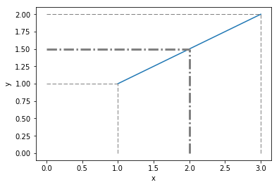

```python
import numpy as np
import matplotlib.pyplot as plt
%matplotlib inline

# (1,1), (3,2)
x = np.array([1,3])
y = np.array([1,2])
plt.plot(x,y, markersize=10)
plt.plot([0, 1], [1,1], color='grey', linewidth=1,linestyle='dashed')
plt.plot([1,1],[0,1], color='grey', linewidth=1,linestyle='dashed')
plt.plot([0, 3], [2,2], color='grey', linewidth=1,linestyle='dashed')
plt.plot([3,3],[0,2], color='grey', linewidth=1,linestyle='dashed')
plt.plot([0, 2], [1.5,1.5], color='grey', linewidth=3,linestyle='dashdot')
plt.plot([2,2],[0,1.5], color='grey', linewidth=3,linestyle='dashdot')

plt.xlabel('x')
plt.ylabel('y')
plt.show()
```

# What's next?

### Approximation theory (*review*)

What if a system of equations have no solution?

$$ \mathbf{A} \cdot \mathbf{x} = \mathbf{b} $$

**Approximation theory** is concerned with *how functions can best be approximated with simpler functions*.

- the matrix equation we are interested in $$ \mathbf{A}^{T}\cdot \mathbf{A} \cdot \hat{\mathbf{x}} = \mathbf{A}^{T} \cdot \mathbf{b} $$
- A closely related topic is the approximation of functions by **generalized Fourier series**
  - approximations based on series of **orthogonal vectors (*polynomials*)**
  - **Fourier** and **Karhunen–Loeve** transforms

### Case study: Advertising Data

We'll take a look at some data, ask some questions about that data, and then use linear regression to answer those questions!

*Adapted from Chapter 3 of [An Introduction to Statistical Learning](http://www-bcf.usc.edu/~gareth/ISL/)*

## Comments or Questions?

- Email: cross224@hotmail.com
- GitHub: [@carap](https://github.com/carap)